# Risk Factor Analysis

## Outcome Variable

**Outcome Variable:** haz

## Predictor Variables

**Intervention Variable:** nhh

**Adjustment Set:**

unadjusted

## Stratifying Variables

The analysis was stratified on these variable(s):

- agecat
- studyid
- country

## Data Summary

| agecat | studyid | country | nhh | n_cell | n |
| --- | --- | --- | --- | --- | --- |
| Birth | ki1000108-IRC | INDIA | 3 or less | 54 | 388 |
| Birth | ki1000108-IRC | INDIA | 4-5 | 150 | 388 |
| Birth | ki1000108-IRC | INDIA | 6-7 | 103 | 388 |
| Birth | ki1000108-IRC | INDIA | 8+ | 81 | 388 |
| Birth | ki1017093-NIH-Birth | BANGLADESH | 3 or less | 7 | 28 |
| Birth | ki1017093-NIH-Birth | BANGLADESH | 4-5 | 11 | 28 |
| Birth | ki1017093-NIH-Birth | BANGLADESH | 6-7 | 7 | 28 |
| Birth | ki1017093-NIH-Birth | BANGLADESH | 8+ | 3 | 28 |
| Birth | ki1017093c-NIH-Crypto | BANGLADESH | 3 or less | 8 | 27 |
| Birth | ki1017093c-NIH-Crypto | BANGLADESH | 4-5 | 9 | 27 |
| Birth | ki1017093c-NIH-Crypto | BANGLADESH | 6-7 | 7 | 27 |
| Birth | ki1017093c-NIH-Crypto | BANGLADESH | 8+ | 3 | 27 |
| 6 months | ki1000108-IRC | INDIA | 3 or less | 58 | 407 |
| 6 months | ki1000108-IRC | INDIA | 4-5 | 158 | 407 |
| 6 months | ki1000108-IRC | INDIA | 6-7 | 106 | 407 |
| 6 months | ki1000108-IRC | INDIA | 8+ | 85 | 407 |
| 6 months | ki1000304b-SAS-FoodSuppl | INDIA | 3 or less | 33 | 380 |
| 6 months | ki1000304b-SAS-FoodSuppl | INDIA | 4-5 | 166 | 380 |
| 6 months | ki1000304b-SAS-FoodSuppl | INDIA | 6-7 | 115 | 380 |
| 6 months | ki1000304b-SAS-FoodSuppl | INDIA | 8+ | 66 | 380 |
| 6 months | ki1017093-NIH-Birth | BANGLADESH | 3 or less | 95 | 537 |
| 6 months | ki1017093-NIH-Birth | BANGLADESH | 4-5 | 227 | 537 |
| 6 months | ki1017093-NIH-Birth | BANGLADESH | 6-7 | 128 | 537 |
| 6 months | ki1017093-NIH-Birth | BANGLADESH | 8+ | 87 | 537 |
| 6 months | ki1017093b-PROVIDE | BANGLADESH | 3 or less | 102 | 583 |
| 6 months | ki1017093b-PROVIDE | BANGLADESH | 4-5 | 277 | 583 |
| 6 months | ki1017093b-PROVIDE | BANGLADESH | 6-7 | 126 | 583 |
| 6 months | ki1017093b-PROVIDE | BANGLADESH | 8+ | 78 | 583 |
| 6 months | ki1017093c-NIH-Crypto | BANGLADESH | 3 or less | 104 | 715 |
| 6 months | ki1017093c-NIH-Crypto | BANGLADESH | 4-5 | 326 | 715 |
| 6 months | ki1017093c-NIH-Crypto | BANGLADESH | 6-7 | 170 | 715 |
| 6 months | ki1017093c-NIH-Crypto | BANGLADESH | 8+ | 115 | 715 |
| 6 months | ki1148112-LCNI-5 | MALAWI | 3 or less | 224 | 816 |
| 6 months | ki1148112-LCNI-5 | MALAWI | 4-5 | 340 | 816 |
| 6 months | ki1148112-LCNI-5 | MALAWI | 6-7 | 182 | 816 |
| 6 months | ki1148112-LCNI-5 | MALAWI | 8+ | 70 | 816 |
| 24 months | ki1000108-IRC | INDIA | 3 or less | 58 | 409 |
| 24 months | ki1000108-IRC | INDIA | 4-5 | 158 | 409 |
| 24 months | ki1000108-IRC | INDIA | 6-7 | 107 | 409 |
| 24 months | ki1000108-IRC | INDIA | 8+ | 86 | 409 |
| 24 months | ki1017093-NIH-Birth | BANGLADESH | 3 or less | 75 | 429 |
| 24 months | ki1017093-NIH-Birth | BANGLADESH | 4-5 | 184 | 429 |
| 24 months | ki1017093-NIH-Birth | BANGLADESH | 6-7 | 100 | 429 |
| 24 months | ki1017093-NIH-Birth | BANGLADESH | 8+ | 70 | 429 |
| 24 months | ki1017093b-PROVIDE | BANGLADESH | 3 or less | 105 | 577 |
| 24 months | ki1017093b-PROVIDE | BANGLADESH | 4-5 | 273 | 577 |
| 24 months | ki1017093b-PROVIDE | BANGLADESH | 6-7 | 117 | 577 |
| 24 months | ki1017093b-PROVIDE | BANGLADESH | 8+ | 82 | 577 |
| 24 months | ki1017093c-NIH-Crypto | BANGLADESH | 3 or less | 69 | 514 |
| 24 months | ki1017093c-NIH-Crypto | BANGLADESH | 4-5 | 232 | 514 |
| 24 months | ki1017093c-NIH-Crypto | BANGLADESH | 6-7 | 130 | 514 |
| 24 months | ki1017093c-NIH-Crypto | BANGLADESH | 8+ | 83 | 514 |
| 24 months | ki1148112-LCNI-5 | MALAWI | 3 or less | 159 | 574 |
| 24 months | ki1148112-LCNI-5 | MALAWI | 4-5 | 237 | 574 |
| 24 months | ki1148112-LCNI-5 | MALAWI | 6-7 | 129 | 574 |
| 24 months | ki1148112-LCNI-5 | MALAWI | 8+ | 49 | 574 |

The following strata were considered:

- agecat: 24 months, studyid: ki1000108-IRC, country: INDIA
- agecat: 24 months, studyid: ki1017093-NIH-Birth, country: BANGLADESH
- agecat: 24 months, studyid: ki1017093b-PROVIDE, country: BANGLADESH
- agecat: 24 months, studyid: ki1017093c-NIH-Crypto, country: BANGLADESH
- agecat: 24 months, studyid: ki1148112-LCNI-5, country: MALAWI
- agecat: 6 months, studyid: ki1000108-IRC, country: INDIA
- agecat: 6 months, studyid: ki1000304b-SAS-FoodSuppl, country: INDIA
- agecat: 6 months, studyid: ki1017093-NIH-Birth, country: BANGLADESH
- agecat: 6 months, studyid: ki1017093b-PROVIDE, country: BANGLADESH
- agecat: 6 months, studyid: ki1017093c-NIH-Crypto, country: BANGLADESH
- agecat: 6 months, studyid: ki1148112-LCNI-5, country: MALAWI
- agecat: Birth, studyid: ki1000108-IRC, country: INDIA
- agecat: Birth, studyid: ki1017093-NIH-Birth, country: BANGLADESH
- agecat: Birth, studyid: ki1017093c-NIH-Crypto, country: BANGLADESH

### Dropped Strata

Some strata were dropped due to rare outcomes:

- agecat: Birth, studyid: ki1017093-NIH-Birth, country: BANGLADESH
- agecat: Birth, studyid: ki1017093c-NIH-Crypto, country: BANGLADESH

## Methods Detail

We’re interested in the causal parameters $E[Y_a]$ for all values of $a \in \mathcal{A}$. These parameters represent the mean outcome if, possibly contrary to fact, we intervened to set all units to have $A=a$. Under the randomization and positivity assumptions, these are identified by the statistical parameters $\psi_a=E_W[E_{Y|A,W}(Y|A=a,W)]$. In addition, we’re interested in the mean of $Y$, $E[Y]$ under no intervention (the observed mean). We will estimate these parameters by using SuperLearner to fit the relevant likelihood factors – $E_{Y|A,W}(Y|A=a,W)$ and $p(A=a|W)$, and then updating our likelihood fit using a joint TMLE.

For unadjusted analyses ($W=\{\}$), initial likelihoods were estimated using Lrnr_glm to estimate the simple $E(Y|A)$ and Lrnr_mean to estimate $p(A)$. For adjusted analyses, a small library containing Lrnr_glmnet, Lrnr_xgboost, and Lrnr_mean was used.

Having estimated these parameters, we will then use the delta method to estimate relative risks and attributable risks relative to a prespecified baseline level of $A$.

# Results Detail

## Results Plots

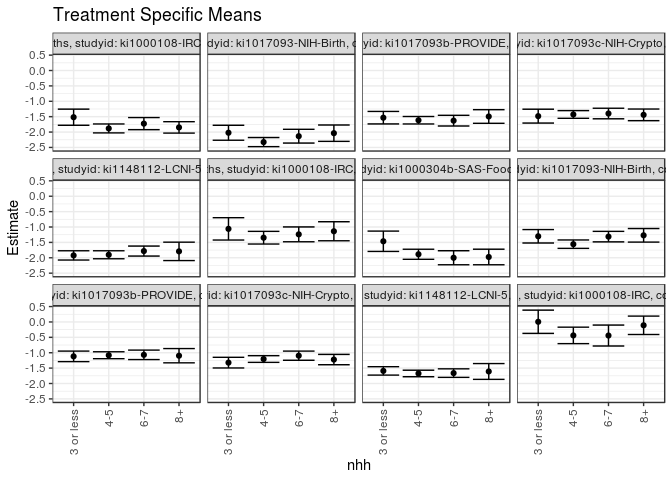

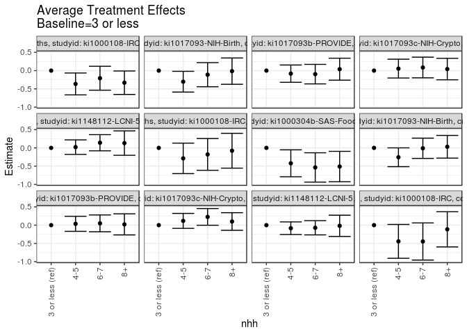

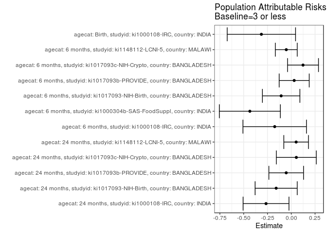

## Results Table

### Parameter: TSM

| agecat | studyid | country | intervention_level | baseline_level | estimate | ci_lower | ci_upper |
| --- | --- | --- | --- | --- | --- | --- | --- |
| Birth | ki1000108-IRC | INDIA | 3 or less | NA | 0.0059259 | -0.3720952 | 0.3839471 |
| Birth | ki1000108-IRC | INDIA | 4-5 | NA | -0.4374000 | -0.7051558 | -0.1696442 |
| Birth | ki1000108-IRC | INDIA | 6-7 | NA | -0.4412621 | -0.7811504 | -0.1013739 |
| Birth | ki1000108-IRC | INDIA | 8+ | NA | -0.1083951 | -0.4070486 | 0.1902585 |
| 6 months | ki1000108-IRC | INDIA | 3 or less | NA | -1.0603161 | -1.4228026 | -0.6978296 |
| 6 months | ki1000108-IRC | INDIA | 4-5 | NA | -1.3470148 | -1.5529446 | -1.1410850 |
| 6 months | ki1000108-IRC | INDIA | 6-7 | NA | -1.2388836 | -1.4798291 | -0.9979382 |
| 6 months | ki1000108-IRC | INDIA | 8+ | NA | -1.1382941 | -1.4476886 | -0.8288996 |
| 6 months | ki1000304b-SAS-FoodSuppl | INDIA | 3 or less | NA | -1.4636364 | -1.7938184 | -1.1334544 |
| 6 months | ki1000304b-SAS-FoodSuppl | INDIA | 4-5 | NA | -1.8856627 | -2.0492713 | -1.7220540 |
| 6 months | ki1000304b-SAS-FoodSuppl | INDIA | 6-7 | NA | -1.9990435 | -2.2267810 | -1.7713059 |
| 6 months | ki1000304b-SAS-FoodSuppl | INDIA | 8+ | NA | -1.9740909 | -2.2268199 | -1.7213620 |
| 6 months | ki1017093-NIH-Birth | BANGLADESH | 3 or less | NA | -1.3012456 | -1.5199922 | -1.0824990 |
| 6 months | ki1017093-NIH-Birth | BANGLADESH | 4-5 | NA | -1.5579919 | -1.6941634 | -1.4218205 |
| 6 months | ki1017093-NIH-Birth | BANGLADESH | 6-7 | NA | -1.3121484 | -1.4827021 | -1.1415948 |
| 6 months | ki1017093-NIH-Birth | BANGLADESH | 8+ | NA | -1.2704215 | -1.4912353 | -1.0496076 |
| 6 months | ki1017093b-PROVIDE | BANGLADESH | 3 or less | NA | -1.1177941 | -1.2891832 | -0.9464050 |
| 6 months | ki1017093b-PROVIDE | BANGLADESH | 4-5 | NA | -1.0816968 | -1.1945921 | -0.9688014 |
| 6 months | ki1017093b-PROVIDE | BANGLADESH | 6-7 | NA | -1.0682275 | -1.2219089 | -0.9145461 |
| 6 months | ki1017093b-PROVIDE | BANGLADESH | 8+ | NA | -1.0966667 | -1.3286429 | -0.8646905 |
| 6 months | ki1017093c-NIH-Crypto | BANGLADESH | 3 or less | NA | -1.3220673 | -1.4955380 | -1.1485966 |
| 6 months | ki1017093c-NIH-Crypto | BANGLADESH | 4-5 | NA | -1.2045706 | -1.3133029 | -1.0958382 |
| 6 months | ki1017093c-NIH-Crypto | BANGLADESH | 6-7 | NA | -1.0960294 | -1.2448367 | -0.9472222 |
| 6 months | ki1017093c-NIH-Crypto | BANGLADESH | 8+ | NA | -1.2221304 | -1.3898819 | -1.0543789 |
| 6 months | ki1148112-LCNI-5 | MALAWI | 3 or less | NA | -1.5903125 | -1.7269478 | -1.4536772 |
| 6 months | ki1148112-LCNI-5 | MALAWI | 4-5 | NA | -1.6739706 | -1.7800476 | -1.5678936 |
| 6 months | ki1148112-LCNI-5 | MALAWI | 6-7 | NA | -1.6618681 | -1.8007284 | -1.5230078 |
| 6 months | ki1148112-LCNI-5 | MALAWI | 8+ | NA | -1.6085714 | -1.8654233 | -1.3517195 |
| 24 months | ki1000108-IRC | INDIA | 3 or less | NA | -1.5172701 | -1.7794683 | -1.2550720 |
| 24 months | ki1000108-IRC | INDIA | 4-5 | NA | -1.8821097 | -2.0276386 | -1.7365808 |
| 24 months | ki1000108-IRC | INDIA | 6-7 | NA | -1.7259969 | -1.9225450 | -1.5294488 |
| 24 months | ki1000108-IRC | INDIA | 8+ | NA | -1.8485659 | -2.0338543 | -1.6632775 |
| 24 months | ki1017093-NIH-Birth | BANGLADESH | 3 or less | NA | -2.0221556 | -2.2650065 | -1.7793046 |
| 24 months | ki1017093-NIH-Birth | BANGLADESH | 4-5 | NA | -2.3257699 | -2.4734648 | -2.1780751 |
| 24 months | ki1017093-NIH-Birth | BANGLADESH | 6-7 | NA | -2.1340167 | -2.3575847 | -1.9104486 |
| 24 months | ki1017093-NIH-Birth | BANGLADESH | 8+ | NA | -2.0365119 | -2.3022591 | -1.7707647 |
| 24 months | ki1017093b-PROVIDE | BANGLADESH | 3 or less | NA | -1.5329524 | -1.7360559 | -1.3298489 |
| 24 months | ki1017093b-PROVIDE | BANGLADESH | 4-5 | NA | -1.6156410 | -1.7372098 | -1.4940723 |
| 24 months | ki1017093b-PROVIDE | BANGLADESH | 6-7 | NA | -1.6294872 | -1.8034033 | -1.4555711 |
| 24 months | ki1017093b-PROVIDE | BANGLADESH | 8+ | NA | -1.4940244 | -1.7160449 | -1.2720039 |
| 24 months | ki1017093c-NIH-Crypto | BANGLADESH | 3 or less | NA | -1.4827536 | -1.7080531 | -1.2574542 |
| 24 months | ki1017093c-NIH-Crypto | BANGLADESH | 4-5 | NA | -1.4277155 | -1.5528992 | -1.3025319 |
| 24 months | ki1017093c-NIH-Crypto | BANGLADESH | 6-7 | NA | -1.3974615 | -1.5690694 | -1.2258537 |
| 24 months | ki1017093c-NIH-Crypto | BANGLADESH | 8+ | NA | -1.4406024 | -1.6297342 | -1.2514706 |
| 24 months | ki1148112-LCNI-5 | MALAWI | 3 or less | NA | -1.9227673 | -2.0732560 | -1.7722786 |
| 24 months | ki1148112-LCNI-5 | MALAWI | 4-5 | NA | -1.9023629 | -2.0324129 | -1.7723128 |
| 24 months | ki1148112-LCNI-5 | MALAWI | 6-7 | NA | -1.7818605 | -1.9441978 | -1.6195231 |
| 24 months | ki1148112-LCNI-5 | MALAWI | 8+ | NA | -1.7914286 | -2.0899325 | -1.4929246 |

### Parameter: E(Y)

| agecat | studyid | country | intervention_level | baseline_level | estimate | ci_lower | ci_upper |
| --- | --- | --- | --- | --- | --- | --- | --- |
| Birth | ki1000108-IRC | INDIA | NA | NA | -0.3080412 | -0.4687931 | -0.1472894 |
| 6 months | ki1000108-IRC | INDIA | NA | NA | -1.2344062 | -1.3658524 | -1.1029600 |
| 6 months | ki1000304b-SAS-FoodSuppl | INDIA | NA | NA | -1.8986842 | -2.0118892 | -1.7854792 |
| 6 months | ki1017093-NIH-Birth | BANGLADESH | NA | NA | -1.4073821 | -1.4960598 | -1.3187043 |
| 6 months | ki1017093b-PROVIDE | BANGLADESH | NA | NA | -1.0871041 | -1.1635539 | -1.0106543 |
| 6 months | ki1017093c-NIH-Crypto | BANGLADESH | NA | NA | -1.1986783 | -1.2700937 | -1.1272630 |
| 6 months | ki1148112-LCNI-5 | MALAWI | NA | NA | -1.6426961 | -1.7120603 | -1.5733318 |
| 24 months | ki1000108-IRC | INDIA | NA | NA | -1.7824776 | -1.8765600 | -1.6883952 |
| 24 months | ki1017093-NIH-Birth | BANGLADESH | NA | NA | -2.1807945 | -2.2835902 | -2.0779987 |
| 24 months | ki1017093b-PROVIDE | BANGLADESH | NA | NA | -1.5861179 | -1.6693668 | -1.5028689 |
| 24 months | ki1017093c-NIH-Crypto | BANGLADESH | NA | NA | -1.4295331 | -1.5127726 | -1.3462935 |
| 24 months | ki1148112-LCNI-5 | MALAWI | NA | NA | -1.8714634 | -1.9528558 | -1.7900711 |

### Parameter: ATE

| agecat | studyid | country | intervention_level | baseline_level | estimate | ci_lower | ci_upper |
| --- | --- | --- | --- | --- | --- | --- | --- |
| Birth | ki1000108-IRC | INDIA | 3 or less | 3 or less | 0.0000000 | 0.0000000 | 0.0000000 |
| Birth | ki1000108-IRC | INDIA | 4-5 | 3 or less | -0.4433259 | -0.9065680 | 0.0199161 |
| Birth | ki1000108-IRC | INDIA | 6-7 | 3 or less | -0.4471881 | -0.9555423 | 0.0611662 |
| Birth | ki1000108-IRC | INDIA | 8+ | 3 or less | -0.1143210 | -0.5960823 | 0.3674403 |
| 6 months | ki1000108-IRC | INDIA | 3 or less | 3 or less | 0.0000000 | 0.0000000 | 0.0000000 |
| 6 months | ki1000108-IRC | INDIA | 4-5 | 3 or less | -0.2866987 | -0.7035962 | 0.1301988 |
| 6 months | ki1000108-IRC | INDIA | 6-7 | 3 or less | -0.1785676 | -0.6138274 | 0.2566923 |
| 6 months | ki1000108-IRC | INDIA | 8+ | 3 or less | -0.0779780 | -0.5545506 | 0.3985945 |
| 6 months | ki1000304b-SAS-FoodSuppl | INDIA | 3 or less | 3 or less | 0.0000000 | 0.0000000 | 0.0000000 |
| 6 months | ki1000304b-SAS-FoodSuppl | INDIA | 4-5 | 3 or less | -0.4220263 | -0.7905204 | -0.0535321 |
| 6 months | ki1000304b-SAS-FoodSuppl | INDIA | 6-7 | 3 or less | -0.5354071 | -0.9365113 | -0.1343030 |
| 6 months | ki1000304b-SAS-FoodSuppl | INDIA | 8+ | 3 or less | -0.5104545 | -0.9262575 | -0.0946516 |
| 6 months | ki1017093-NIH-Birth | BANGLADESH | 3 or less | 3 or less | 0.0000000 | 0.0000000 | 0.0000000 |
| 6 months | ki1017093-NIH-Birth | BANGLADESH | 4-5 | 3 or less | -0.2567463 | -0.5144142 | 0.0009216 |
| 6 months | ki1017093-NIH-Birth | BANGLADESH | 6-7 | 3 or less | -0.0109028 | -0.2882810 | 0.2664753 |
| 6 months | ki1017093-NIH-Birth | BANGLADESH | 8+ | 3 or less | 0.0308242 | -0.2799955 | 0.3416438 |
| 6 months | ki1017093b-PROVIDE | BANGLADESH | 3 or less | 3 or less | 0.0000000 | 0.0000000 | 0.0000000 |
| 6 months | ki1017093b-PROVIDE | BANGLADESH | 4-5 | 3 or less | 0.0360974 | -0.1691332 | 0.2413279 |
| 6 months | ki1017093b-PROVIDE | BANGLADESH | 6-7 | 3 or less | 0.0495666 | -0.1806338 | 0.2797670 |
| 6 months | ki1017093b-PROVIDE | BANGLADESH | 8+ | 3 or less | 0.0211275 | -0.2672944 | 0.3095493 |
| 6 months | ki1017093c-NIH-Crypto | BANGLADESH | 3 or less | 3 or less | 0.0000000 | 0.0000000 | 0.0000000 |
| 6 months | ki1017093c-NIH-Crypto | BANGLADESH | 4-5 | 3 or less | 0.1174968 | -0.0872343 | 0.3222278 |
| 6 months | ki1017093c-NIH-Crypto | BANGLADESH | 6-7 | 3 or less | 0.2260379 | -0.0025134 | 0.4545892 |
| 6 months | ki1017093c-NIH-Crypto | BANGLADESH | 8+ | 3 or less | 0.0999369 | -0.1413775 | 0.3412513 |
| 6 months | ki1148112-LCNI-5 | MALAWI | 3 or less | 3 or less | 0.0000000 | 0.0000000 | 0.0000000 |
| 6 months | ki1148112-LCNI-5 | MALAWI | 4-5 | 3 or less | -0.0836581 | -0.2566365 | 0.0893204 |
| 6 months | ki1148112-LCNI-5 | MALAWI | 6-7 | 3 or less | -0.0715556 | -0.2663668 | 0.1232555 |
| 6 months | ki1148112-LCNI-5 | MALAWI | 8+ | 3 or less | -0.0182589 | -0.3091921 | 0.2726742 |
| 24 months | ki1000108-IRC | INDIA | 3 or less | 3 or less | 0.0000000 | 0.0000000 | 0.0000000 |
| 24 months | ki1000108-IRC | INDIA | 4-5 | 3 or less | -0.3648396 | -0.6647171 | -0.0649621 |
| 24 months | ki1000108-IRC | INDIA | 6-7 | 3 or less | -0.2087268 | -0.5364141 | 0.1189606 |
| 24 months | ki1000108-IRC | INDIA | 8+ | 3 or less | -0.3312958 | -0.6523560 | -0.0102356 |
| 24 months | ki1017093-NIH-Birth | BANGLADESH | 3 or less | 3 or less | 0.0000000 | 0.0000000 | 0.0000000 |
| 24 months | ki1017093-NIH-Birth | BANGLADESH | 4-5 | 3 or less | -0.3036144 | -0.5878508 | -0.0193779 |
| 24 months | ki1017093-NIH-Birth | BANGLADESH | 6-7 | 3 or less | -0.1118611 | -0.4419509 | 0.2182287 |
| 24 months | ki1017093-NIH-Birth | BANGLADESH | 8+ | 3 or less | -0.0143563 | -0.3743538 | 0.3456411 |
| 24 months | ki1017093b-PROVIDE | BANGLADESH | 3 or less | 3 or less | 0.0000000 | 0.0000000 | 0.0000000 |
| 24 months | ki1017093b-PROVIDE | BANGLADESH | 4-5 | 3 or less | -0.0826886 | -0.3193952 | 0.1540179 |
| 24 months | ki1017093b-PROVIDE | BANGLADESH | 6-7 | 3 or less | -0.0965348 | -0.3639256 | 0.1708560 |
| 24 months | ki1017093b-PROVIDE | BANGLADESH | 8+ | 3 or less | 0.0389280 | -0.2619775 | 0.3398335 |
| 24 months | ki1017093c-NIH-Crypto | BANGLADESH | 3 or less | 3 or less | 0.0000000 | 0.0000000 | 0.0000000 |
| 24 months | ki1017093c-NIH-Crypto | BANGLADESH | 4-5 | 3 or less | 0.0550381 | -0.2027036 | 0.3127798 |
| 24 months | ki1017093c-NIH-Crypto | BANGLADESH | 6-7 | 3 or less | 0.0852921 | -0.1979200 | 0.3685042 |
| 24 months | ki1017093c-NIH-Crypto | BANGLADESH | 8+ | 3 or less | 0.0421512 | -0.2520097 | 0.3363122 |
| 24 months | ki1148112-LCNI-5 | MALAWI | 3 or less | 3 or less | 0.0000000 | 0.0000000 | 0.0000000 |
| 24 months | ki1148112-LCNI-5 | MALAWI | 4-5 | 3 or less | 0.0204044 | -0.1784922 | 0.2193010 |
| 24 months | ki1148112-LCNI-5 | MALAWI | 6-7 | 3 or less | 0.1409068 | -0.0804532 | 0.3622669 |
| 24 months | ki1148112-LCNI-5 | MALAWI | 8+ | 3 or less | 0.1313387 | -0.2029537 | 0.4656312 |

### Parameter: PAR

| agecat | studyid | country | intervention_level | baseline_level | estimate | ci_lower | ci_upper |
| --- | --- | --- | --- | --- | --- | --- | --- |
| Birth | ki1000108-IRC | INDIA | 3 or less | NA | -0.3139672 | -0.6730840 | 0.0451496 |
| 6 months | ki1000108-IRC | INDIA | 3 or less | NA | -0.1740901 | -0.5075942 | 0.1594139 |
| 6 months | ki1000304b-SAS-FoodSuppl | INDIA | 3 or less | NA | -0.4350478 | -0.7558289 | -0.1142668 |
| 6 months | ki1017093-NIH-Birth | BANGLADESH | 3 or less | NA | -0.1061364 | -0.3030720 | 0.0907991 |
| 6 months | ki1017093b-PROVIDE | BANGLADESH | 3 or less | NA | 0.0306901 | -0.1272351 | 0.1886152 |
| 6 months | ki1017093c-NIH-Crypto | BANGLADESH | 3 or less | NA | 0.1233890 | -0.0392092 | 0.2859872 |
| 6 months | ki1148112-LCNI-5 | MALAWI | 3 or less | NA | -0.0523836 | -0.1674090 | 0.0626418 |
| 24 months | ki1000108-IRC | INDIA | 3 or less | NA | -0.2652075 | -0.5062494 | -0.0241656 |
| 24 months | ki1017093-NIH-Birth | BANGLADESH | 3 or less | NA | -0.1586389 | -0.3798230 | 0.0625451 |
| 24 months | ki1017093b-PROVIDE | BANGLADESH | 3 or less | NA | -0.0531655 | -0.2352864 | 0.1289555 |
| 24 months | ki1017093c-NIH-Crypto | BANGLADESH | 3 or less | NA | 0.0532205 | -0.1566855 | 0.2631266 |
| 24 months | ki1148112-LCNI-5 | MALAWI | 3 or less | NA | 0.0513039 | -0.0780215 | 0.1806292 |